# BFA1-2008

Author

Grasland C.

## Fonds de carte

On utilise le découpage de premier niveau du pays.

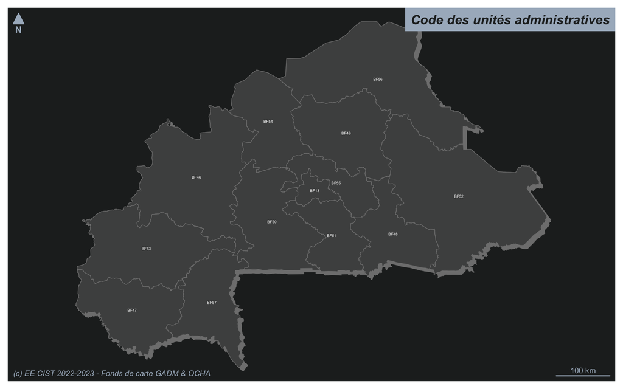

## Matrice de migration totale

On extrait la matrice de migration totale puis on calcule pour chaque paire de régions le solde et le volume des échanges.

```
# A tibble: 6 × 12
# Groups:   i [1]
  i     j     Ni    Nj      Fij   Fji   FVij  FSij      Xi     Yi      Xj     Yj
  <chr> <chr> <chr> <chr> <dbl> <dbl>  <dbl> <dbl>   <dbl>  <dbl>   <dbl>  <dbl>
1 BF13  BF46  Cent… Bouc…  6060 37900  43960 31840 -1.67e5 1.38e6 -3.88e5 1.41e6
2 BF13  BF47  Cent… Casc…  4330  6530  10860  2200 -1.67e5 1.38e6 -5.09e5 1.16e6
3 BF13  BF48  Cent… Cent…  7750 37570  45320 29820 -1.67e5 1.38e6 -2.07e4 1.30e6
4 BF13  BF49  Cent… Cent…  5380 29910  35290 24530 -1.67e5 1.38e6 -1.09e5 1.49e6
5 BF13  BF50  Cent… Cent… 16160 56180  72340 40020 -1.67e5 1.38e6 -2.47e5 1.32e6
6 BF13  BF51  Cent… Cent… 10540 97980 108520 87440 -1.67e5 1.38e6 -1.36e5 1.30e6
```

```
      i                  j                  Ni                 Nj
 Length:156         Length:156         Length:156         Length:156
 Class :character   Class :character   Class :character   Class :character
 Mode  :character   Mode  :character   Mode  :character   Mode  :character



      Fij             Fji             FVij             FSij
 Min.   :  200   Min.   :  200   Min.   :   860   Min.   :-87440
 1st Qu.: 1088   1st Qu.: 1088   1st Qu.:  2840   1st Qu.: -3632
 Median : 3025   Median : 3025   Median :  9020   Median :     0
 Mean   : 8892   Mean   : 8892   Mean   : 17784   Mean   :     0
 3rd Qu.:10080   3rd Qu.:10080   3rd Qu.: 20250   3rd Qu.:  3632
 Max.   :97980   Max.   :97980   Max.   :108520   Max.   : 87440
       Xi                Yi                Xj                Yj
 Min.   :-508788   Min.   :1158718   Min.   :-508788   Min.   :1158718
 1st Qu.:-359652   1st Qu.:1298323   1st Qu.:-359652   1st Qu.:1298323
 Median :-167235   Median :1371906   Median :-167235   Median :1371906
 Mean   :-211278   Mean   :1360149   Mean   :-211278   Mean   :1360149
 3rd Qu.:-108500   3rd Qu.:1407499   3rd Qu.:-108500   3rd Qu.:1407499
 Max.   : 102358   Max.   :1591193   Max.   : 102358   Max.   :1591193
```

### Volume

On représente les volumes de flux dont la valeur est supérieure à la moyenne .

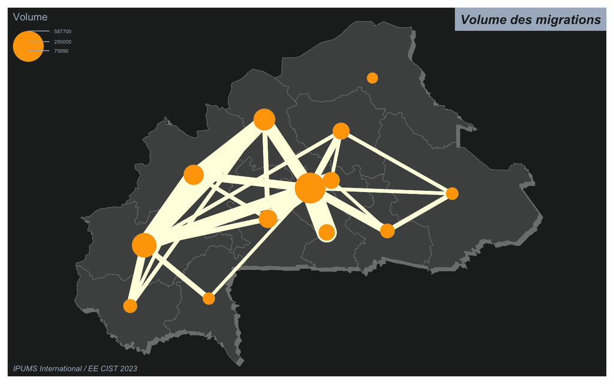

### Solde

On représente les soldes de flux dont la valeur est supérieure à la moyenne .

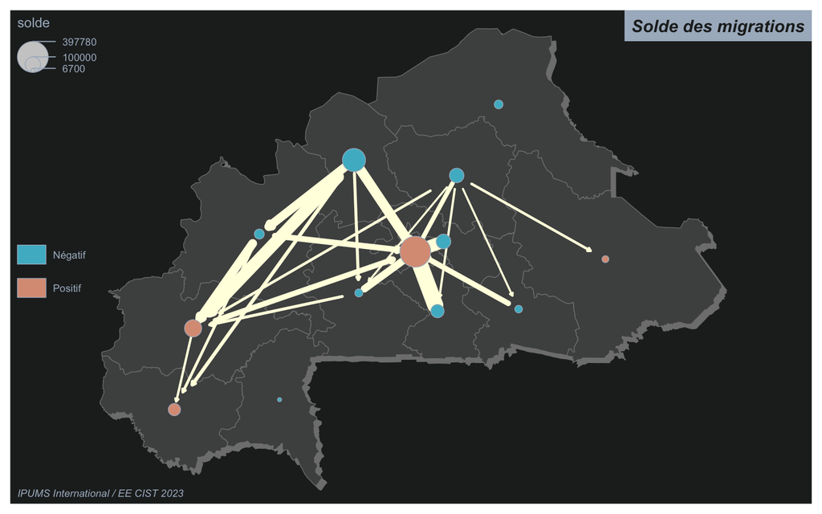

### Flux dominant

On détermine pour chaque unité spatiale son flux le plus important vers une autre unité spatiale. On considère qu’une unité est de type :

- **dominante** si son nombre si son nombre d’arrivée est supérieur à l’unité vers laquelle elle envoie son plus grand flux.
- **dominée** si son nombre d’arrivée est inférieur à l’unité vers laquelle elle envoie son plus grand flux.
- **relais** si elle est à la fois dominée et dominante.

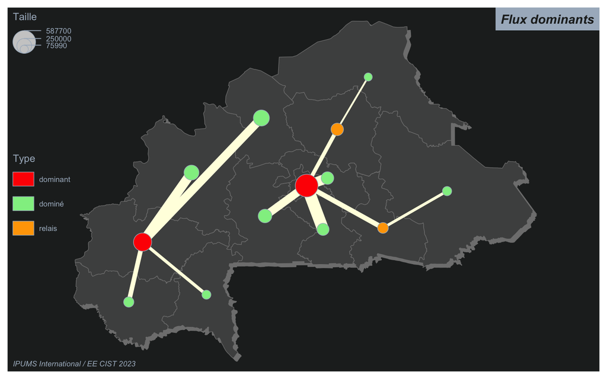